# Study 1: Point duration in English-learners, ASL-learners and homesigners

# 3 All points

```r
prior_check <- brm(log_duration ~ language_group + (1 | subject) + (1 | age_numeric),
                   data = all_points, prior = std_priors, family = gaussian(),
                   sample_prior = "only", chains = 2, iter = 1000, warmup = 500,
                   seed = SEED, silent = 2, refresh = 0)
round(quantile(exp(posterior_predict(prior_check, ndraws = 500)), c(0.05, 0.5, 0.95)), 2)
```

```
##    5%   50%   95%
##  0.01  0.98 61.30
```

```r
round(quantile(all_points$duration_sec, c(0.05, 0.5, 0.95)), 2)
```

```
##   5%  50%  95%
## 0.25 1.04 3.76
```

The prior predictive distribution (first line, seconds) is wider than the observed durations (second line) and places little mass on implausible values.

```r
m_all <- fit("dur_all_full",
             log_duration ~ language_group + (1 | subject) + (1 | age_numeric), all_points)
kable(convergence(m_all, "All points"), digits = 3)
```

| model | N | max_rhat | bulk_ess_fixed | bulk_ess_all | tail_ess_all | divergences |
| --- | --- | --- | --- | --- | --- | --- |
| All points | 2428 | 1.002 | 3621.64 | 2842.225 | 3589.184 | 0 |

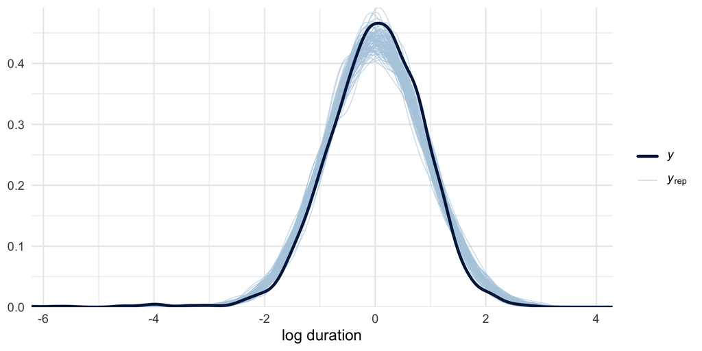

```r
pp_check(m_all, ndraws = 100) + labs(x = "log duration") + theme_minimal()
```

```r
report(m_all, "All points")
```

```
##
##
## Table: All points - geometric mean duration (s)
##
## |language_group | mean_s| lower| upper|
## |:--------------|------:|-----:|-----:|
## |English-Points |   1.49|  1.22|  1.79|
## |ASL            |   0.83|  0.66|  1.03|
## |Homesign       |   1.08|  0.86|  1.35|
##
##
## Table: All points - contrasts (log-seconds)
##
## |term               | estimate|  lower|  upper|     P|
## |:------------------|--------:|------:|------:|-----:|
## |English - ASL      |    0.590|  0.381|  0.779| 1.000|
## |English - homesign |    0.324|  0.093|  0.547| 0.983|
## |ASL - homesign     |   -0.267| -0.515| -0.017| 0.954|
```

## 3.1 Semantic controls

Each model adds one semantic covariate: the nine semantic roles, entity versus other roles, or action versus static roles.

```r
m_all_roles  <- fit("sem_all_full_cat_full",
                    log_duration ~ language_group + semantic_cat + (1 | subject) + (1 | age_numeric),
                    sem_all)
m_all_entity <- fit("sem_all_entoth_full",
                    log_duration ~ language_group + entity_vs_other + (1 | subject) + (1 | age_numeric),
                    binary_subset(sem_all, "entity_vs_other"))
m_all_action <- fit("sem_all_acstat_full",
                    log_duration ~ language_group + action_vs_static + (1 | subject) + (1 | age_numeric),
                    binary_subset(sem_all, "action_vs_static"))
report(m_all_roles,  "All points + all roles")
```

```
##
##
## Table: All points + all roles - geometric mean duration (s)
##
## |language_group | mean_s| lower| upper|
## |:--------------|------:|-----:|-----:|
## |English-Points |   1.38|  1.14|  1.64|
## |ASL            |   0.83|  0.65|  1.03|
## |Homesign       |   1.13|  0.89|  1.42|
##
##
## Table: All points + all roles - contrasts (log-seconds)
##
## |term               | estimate|  lower|  upper|     P|
## |:------------------|--------:|------:|------:|-----:|
## |English - ASL      |    0.511|  0.277|  0.733| 0.999|
## |English - homesign |    0.199| -0.048|  0.439| 0.906|
## |ASL - homesign     |   -0.311| -0.587| -0.038| 0.964|
```

```r
report(m_all_entity, "All points + entity vs. other")
```

```
##
##
## Table: All points + entity vs. other - geometric mean duration (s)
##
## |language_group | mean_s| lower| upper|
## |:--------------|------:|-----:|-----:|
## |English-Points |   1.48|  1.24|  1.75|
## |ASL            |   0.87|  0.69|  1.07|
## |Homesign       |   1.22|  0.97|  1.51|
##
##
## Table: All points + entity vs. other - contrasts (log-seconds)
##
## |term               | estimate|  lower|  upper|     P|
## |:------------------|--------:|------:|------:|-----:|
## |English - ASL      |    0.543|  0.310|  0.758| 0.999|
## |English - homesign |    0.198| -0.045|  0.431| 0.907|
## |ASL - homesign     |   -0.345| -0.619| -0.068| 0.972|
```

```r
report(m_all_action, "All points + action vs. static")
```

```
##
##
## Table: All points + action vs. static - geometric mean duration (s)
##
## |language_group | mean_s| lower| upper|
## |:--------------|------:|-----:|-----:|
## |English-Points |   1.45|  1.21|  1.72|
## |ASL            |   0.85|  0.67|  1.05|
## |Homesign       |   1.21|  0.96|  1.51|
##
##
## Table: All points + action vs. static - contrasts (log-seconds)
##
## |term               | estimate|  lower|  upper|     P|
## |:------------------|--------:|------:|------:|-----:|
## |English - ASL      |    0.544|  0.307|  0.767| 0.999|
## |English - homesign |    0.188| -0.058|  0.428| 0.894|
## |ASL - homesign     |   -0.356| -0.631| -0.069| 0.972|
```

# 4 Points produced alone

```r
m_iso <- fit("foc_full_age",
             log_duration ~ language_group + (1 | subject) + (1 | age_numeric), isolated_points)
kable(convergence(m_iso, "Isolated points"), digits = 3)
```

| model | N | max_rhat | bulk_ess_fixed | bulk_ess_all | tail_ess_all | divergences |
| --- | --- | --- | --- | --- | --- | --- |
| Isolated points | 1044 | 1.002 | 3273.617 | 2469.707 | 2796.077 | 0 |

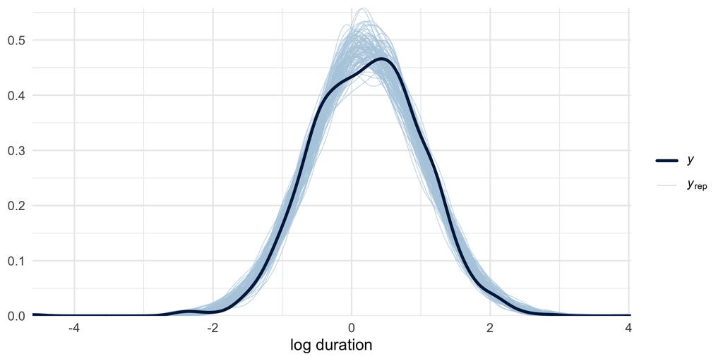

```r
pp_check(m_iso, ndraws = 100) + labs(x = "log duration") + theme_minimal()
```

```r
report(m_iso, "Isolated points")
```

```
##
##
## Table: Isolated points - geometric mean duration (s)
##
## |language_group | mean_s| lower| upper|
## |:--------------|------:|-----:|-----:|
## |English-Points |   1.61|  1.27|  1.96|
## |ASL            |   1.18|  0.90|  1.50|
## |Homesign       |   1.22|  0.94|  1.55|
##
##
## Table: Isolated points - contrasts (log-seconds)
##
## |term               | estimate|  lower| upper|     P|
## |:------------------|--------:|------:|-----:|-----:|
## |English - ASL      |    0.314|  0.006| 0.594| 0.947|
## |English - homesign |    0.277| -0.031| 0.561| 0.929|
## |ASL - homesign     |   -0.037| -0.365| 0.301| 0.575|
```

```r
# Region of practical equivalence for the ASL - homesign contrast: proportion
# of all posterior draws within +/-0.10 and +/-0.20 log-units.
asl_hs_iso <- with(group_draws(m_iso), ASL - Homesign)
c(within_0.10 = mean(abs(asl_hs_iso) < 0.10), within_0.20 = mean(abs(asl_hs_iso) < 0.20))
```

```
## within_0.10 within_0.20
##    0.388875    0.679375
```

```r
# Standard deviation of the age random intercept
summ(as_draws_df(m_iso)$sd_age_numeric__Intercept, "SD of age intercept")
```

```
##                  term  estimate      lower     upper p_positive
## 1 SD of age intercept 0.1480035 0.05126053 0.2832376          1
```

## 4.1 Semantic controls

```r
m_iso_roles  <- fit("sem_foc_full_cat_full_age",
                    log_duration ~ language_group + semantic_cat + (1 | subject) + (1 | age_numeric),
                    sem_isolated)
m_iso_entity <- fit("sem_foc_entoth_full_age",
                    log_duration ~ language_group + entity_vs_other + (1 | subject) + (1 | age_numeric),
                    binary_subset(sem_isolated, "entity_vs_other"))
m_iso_action <- fit("sem_foc_acstat_full_age",
                    log_duration ~ language_group + action_vs_static + (1 | subject) + (1 | age_numeric),
                    binary_subset(sem_isolated, "action_vs_static"))
report(m_iso_roles,  "Isolated + all roles")
```

```
##
##
## Table: Isolated + all roles - geometric mean duration (s)
##
## |language_group | mean_s| lower| upper|
## |:--------------|------:|-----:|-----:|
## |English-Points |   1.36|  1.03|  1.72|
## |ASL            |   1.06|  0.80|  1.36|
## |Homesign       |   1.15|  0.86|  1.48|
##
##
## Table: Isolated + all roles - contrasts (log-seconds)
##
## |term               | estimate|  lower| upper|     P|
## |:------------------|--------:|------:|-----:|-----:|
## |English - ASL      |    0.254| -0.049| 0.534| 0.917|
## |English - homesign |    0.174| -0.127| 0.456| 0.832|
## |ASL - homesign     |   -0.080| -0.391| 0.232| 0.672|
```

```r
report(m_iso_entity, "Isolated + entity vs. other")
```

```
##
##
## Table: Isolated + entity vs. other - geometric mean duration (s)
##
## |language_group | mean_s| lower| upper|
## |:--------------|------:|-----:|-----:|
## |English-Points |   1.47|  1.15|  1.80|
## |ASL            |   1.14|  0.88|  1.43|
## |Homesign       |   1.22|  0.96|  1.54|
##
##
## Table: Isolated + entity vs. other - contrasts (log-seconds)
##
## |term               | estimate|  lower| upper|     P|
## |:------------------|--------:|------:|-----:|-----:|
## |English - ASL      |    0.258| -0.039| 0.544| 0.923|
## |English - homesign |    0.185| -0.111| 0.466| 0.854|
## |ASL - homesign     |   -0.073| -0.393| 0.231| 0.649|
```

```r
report(m_iso_action, "Isolated + action vs. static")
```

```
##
##
## Table: Isolated + action vs. static - geometric mean duration (s)
##
## |language_group | mean_s| lower| upper|
## |:--------------|------:|-----:|-----:|
## |English-Points |   1.48|  1.16|  1.81|
## |ASL            |   1.12|  0.87|  1.42|
## |Homesign       |   1.22|  0.94|  1.54|
##
##
## Table: Isolated + action vs. static - contrasts (log-seconds)
##
## |term               | estimate|  lower| upper|     P|
## |:------------------|--------:|------:|-----:|-----:|
## |English - ASL      |    0.282| -0.031| 0.565| 0.929|
## |English - homesign |    0.195| -0.105| 0.474| 0.860|
## |ASL - homesign     |   -0.087| -0.404| 0.239| 0.681|
```

## 4.2 Without the age intercept

The same four models without the age random intercept (Table S3).

```r
m_iso_noage        <- fit("foc_full",
                          log_duration ~ language_group + (1 | subject), isolated_points)
m_iso_roles_noage  <- fit("sem_foc_full_cat_full",
                          log_duration ~ language_group + semantic_cat + (1 | subject),
                          sem_isolated)
m_iso_entity_noage <- fit("sem_foc_entoth_full",
                          log_duration ~ language_group + entity_vs_other + (1 | subject),
                          binary_subset(sem_isolated, "entity_vs_other"))
m_iso_action_noage <- fit("sem_foc_acstat_full",
                          log_duration ~ language_group + action_vs_static + (1 | subject),
                          binary_subset(sem_isolated, "action_vs_static"))
report(m_iso_noage,        "Isolated, no age intercept")
```

```
##
##
## Table: Isolated, no age intercept - geometric mean duration (s)
##
## |language_group | mean_s| lower| upper|
## |:--------------|------:|-----:|-----:|
## |English-Points |   1.79|  1.49|  2.09|
## |ASL            |   1.18|  0.93|  1.47|
## |Homesign       |   1.27|  0.99|  1.60|
##
##
## Table: Isolated, no age intercept - contrasts (log-seconds)
##
## |term               | estimate|  lower| upper|     P|
## |:------------------|--------:|------:|-----:|-----:|
## |English - ASL      |    0.425|  0.127| 0.693| 0.984|
## |English - homesign |    0.351|  0.054| 0.622| 0.967|
## |ASL - homesign     |   -0.074| -0.394| 0.264| 0.654|
```

```r
report(m_iso_roles_noage,  "Isolated + all roles, no age intercept")
```

```
##
##
## Table: Isolated + all roles, no age intercept - geometric mean duration (s)
##
## |language_group | mean_s| lower| upper|
## |:--------------|------:|-----:|-----:|
## |English-Points |   1.53|  1.24|  1.84|
## |ASL            |   1.06|  0.83|  1.35|
## |Homesign       |   1.17|  0.90|  1.49|
##
##
## Table: Isolated + all roles, no age intercept - contrasts (log-seconds)
##
## |term               | estimate|  lower| upper|     P|
## |:------------------|--------:|------:|-----:|-----:|
## |English - ASL      |    0.369|  0.088| 0.626| 0.975|
## |English - homesign |    0.276| -0.006| 0.537| 0.941|
## |ASL - homesign     |   -0.093| -0.414| 0.227| 0.696|
```

```r
report(m_iso_entity_noage, "Isolated + entity vs. other, no age intercept")
```

```
##
##
## Table: Isolated + entity vs. other, no age intercept - geometric mean duration (s)
##
## |language_group | mean_s| lower| upper|
## |:--------------|------:|-----:|-----:|
## |English-Points |   1.64|  1.38|  1.92|
## |ASL            |   1.14|  0.91|  1.42|
## |Homesign       |   1.26|  1.01|  1.57|
##
##
## Table: Isolated + entity vs. other, no age intercept - contrasts (log-seconds)
##
## |term               | estimate|  lower| upper|     P|
## |:------------------|--------:|------:|-----:|-----:|
## |English - ASL      |    0.368|  0.083| 0.624| 0.973|
## |English - homesign |    0.268| -0.012| 0.521| 0.938|
## |ASL - homesign     |   -0.100| -0.415| 0.213| 0.714|
```

```r
report(m_iso_action_noage, "Isolated + action vs. static, no age intercept")
```

```
##
##
## Table: Isolated + action vs. static, no age intercept - geometric mean duration (s)
##
## |language_group | mean_s| lower| upper|
## |:--------------|------:|-----:|-----:|
## |English-Points |   1.64|  1.37|  1.91|
## |ASL            |   1.12|  0.89|  1.38|
## |Homesign       |   1.25|  0.99|  1.55|
##
##
## Table: Isolated + action vs. static, no age intercept - contrasts (log-seconds)
##
## |term               | estimate|  lower| upper|     P|
## |:------------------|--------:|------:|-----:|-----:|
## |English - ASL      |    0.384|  0.105| 0.643| 0.982|
## |English - homesign |    0.274| -0.009| 0.530| 0.940|
## |ASL - homesign     |   -0.109| -0.417| 0.200| 0.732|
```

# 5 Points produced with other words, signs or gestures

```r
m_with_roles  <- fit("sem_pna_full_cat_full",
                     log_duration ~ language_group + semantic_cat + (1 | subject) + (1 | age_numeric),
                     sem_with)
m_with_entity <- fit("sem_pna_entoth_full",
                     log_duration ~ language_group + entity_vs_other + (1 | subject) + (1 | age_numeric),
                     binary_subset(sem_with, "entity_vs_other"))
m_with_action <- fit("sem_pna_acstat_full",
                     log_duration ~ language_group + action_vs_static + (1 | subject) + (1 | age_numeric),
                     binary_subset(sem_with, "action_vs_static"))
report(m_with_roles,  "With other acts + all roles")
```

```
##
##
## Table: With other acts + all roles - geometric mean duration (s)
##
## |language_group | mean_s| lower| upper|
## |:--------------|------:|-----:|-----:|
## |English-Points |   1.52|  1.26|  1.81|
## |ASL            |   0.74|  0.58|  0.93|
## |Homesign       |   1.16|  0.90|  1.48|
##
##
## Table: With other acts + all roles - contrasts (log-seconds)
##
## |term               | estimate|  lower|  upper|     P|
## |:------------------|--------:|------:|------:|-----:|
## |English - ASL      |    0.728|  0.484|  0.950| 1.000|
## |English - homesign |    0.278|  0.009|  0.536| 0.949|
## |ASL - homesign     |   -0.450| -0.737| -0.161| 0.990|
```

```r
report(m_with_entity, "With other acts + entity vs. other")
```

```
##
##
## Table: With other acts + entity vs. other - geometric mean duration (s)
##
## |language_group | mean_s| lower| upper|
## |:--------------|------:|-----:|-----:|
## |English-Points |   1.56|  1.30|  1.83|
## |ASL            |   0.71|  0.57|  0.89|
## |Homesign       |   1.18|  0.93|  1.49|
##
##
## Table: With other acts + entity vs. other - contrasts (log-seconds)
##
## |term               | estimate|  lower|  upper|     P|
## |:------------------|--------:|------:|------:|-----:|
## |English - ASL      |    0.784|  0.541|  1.003| 0.999|
## |English - homesign |    0.278|  0.004|  0.539| 0.947|
## |ASL - homesign     |   -0.506| -0.802| -0.211| 0.995|
```

```r
report(m_with_action, "With other acts + action vs. static")
```

```
##
##
## Table: With other acts + action vs. static - geometric mean duration (s)
##
## |language_group | mean_s| lower| upper|
## |:--------------|------:|-----:|-----:|
## |English-Points |   1.52|  1.27|  1.80|
## |ASL            |   0.71|  0.57|  0.87|
## |Homesign       |   1.17|  0.92|  1.48|
##
##
## Table: With other acts + action vs. static - contrasts (log-seconds)
##
## |term               | estimate|  lower|  upper|     P|
## |:------------------|--------:|------:|------:|-----:|
## |English - ASL      |    0.770|  0.534|  0.988| 1.000|
## |English - homesign |    0.263|  0.001|  0.518| 0.946|
## |ASL - homesign     |   -0.507| -0.788| -0.216| 0.994|
```

# 6 Isolation by group

All points with a coded context, with group, isolation and their interaction as fixed effects (Table S4).

```r
m_ixg <- fit("dur_iso_main_interaction",
             log_duration ~ language_group * isolated + (1 | subject) + (1 | age_numeric),
             iso_by_group_points)
kable(convergence(m_ixg, "Isolation by group"), digits = 3)
```

| model | N | max_rhat | bulk_ess_fixed | bulk_ess_all | tail_ess_all | divergences |
| --- | --- | --- | --- | --- | --- | --- |
| Isolation by group | 2374 | 1.003 | 4227.504 | 2910.981 | 4105.164 | 0 |

```r
emmeans(m_ixg, ~ language_group * isolated) %>% gather_emmeans_draws() %>%
  group_by(language_group, isolated) %>%
  summarise(mean_s = mean(exp(.value)),
            lower = exp(quantile(.value, LO)), upper = exp(quantile(.value, HI)),
            .groups = "drop") %>%
  kable(digits = 2, caption = "Table S4A: geometric mean duration (s) by group and context")
```

Table S4A: geometric mean duration (s) by group and context

| language_group | isolated | mean_s | lower | upper |
| --- | --- | --- | --- | --- |
| English-Points | Not Alone | 1.48 | 1.26 | 1.72 |
| English-Points | Isolated | 1.80 | 1.50 | 2.11 |
| ASL | Not Alone | 0.70 | 0.58 | 0.85 |
| ASL | Isolated | 1.12 | 0.92 | 1.36 |
| Homesign | Not Alone | 0.90 | 0.74 | 1.09 |
| Homesign | Isolated | 1.21 | 0.99 | 1.46 |

```r
d <- as_draws_df(m_ixg)
eng <- d$b_isolatedIsolated
asl <- eng + d$`b_language_groupASL:isolatedIsolated`
hs  <- eng + d$`b_language_groupHomesign:isolatedIsolated`
bind_rows(summ(eng, "Alone - with other acts, English-learners"),
          summ(asl, "Alone - with other acts, ASL-learners"),
          summ(hs,  "Alone - with other acts, homesigners"),
          summ(asl - eng, "ASL-learners vs. English-learners"),
          summ(hs - eng,  "Homesigners vs. English-learners"),
          summ(asl - hs,  "ASL-learners vs. homesigners")) %>%
  kable(digits = 3, caption = "Table S4B: lengthening in isolation (log-seconds)")
```

Table S4B: lengthening in isolation (log-seconds)

| term | estimate | lower | upper | p_positive |
| --- | --- | --- | --- | --- |
| Alone - with other acts, English-learners | 0.189 | 0.076 | 0.302 | 0.997 |
| Alone - with other acts, ASL-learners | 0.468 | 0.394 | 0.543 | 1.000 |
| Alone - with other acts, homesigners | 0.296 | 0.205 | 0.388 | 1.000 |
| ASL-learners vs. English-learners | 0.279 | 0.144 | 0.411 | 1.000 |
| Homesigners vs. English-learners | 0.107 | -0.034 | 0.253 | 0.882 |
| ASL-learners vs. homesigners | 0.172 | 0.054 | 0.289 | 0.990 |

# 7 Robustness of the all-points model

```r
m_all_wide <- fit("dur_all_full_wide_priors",
                  log_duration ~ language_group + (1 | subject) + (1 | age_numeric),
                  all_points, prior = wide_priors)
m_all_sd2  <- fit("dur_all_full_narrow_sd",
                  log_duration ~ language_group + (1 | subject) + (1 | age_numeric),
                  all_points, prior = narrow_sd_priors)

p <- function(m) { d <- group_draws(m)
  c(`English - ASL` = mean(d$`English-Points` > d$ASL),
    `English - homesign` = mean(d$`English-Points` > d$Homesign),
    `ASL - homesign` = mean(d$ASL > d$Homesign)) }
shift <- rbind(primary = p(m_all), wider_priors = p(m_all_wide), sd_exponential_2 = p(m_all_sd2))
kable(shift, digits = 4, caption = "P(contrast > 0) under each prior")
```

P(contrast > 0) under each prior

|  | English - ASL | English - homesign | ASL - homesign |
| --- | --- | --- | --- |
| primary | 0.9998 | 0.9831 | 0.0460 |
| wider_priors | 1.0000 | 0.9884 | 0.0472 |
| sd_exponential_2 | 0.9999 | 0.9836 | 0.0504 |

```r
c(max_shift_wider_priors = max(abs(shift[2, ] - shift[1, ])),
  max_shift_exponential_2 = max(abs(shift[3, ] - shift[1, ])))
```

```
##  max_shift_wider_priors max_shift_exponential_2
##                0.005250                0.004375
```

The Gamma model is fitted to duration in seconds. To compare it with the log-normal model, the log-normal model’s pointwise log-likelihood is moved to the seconds scale with the Jacobian of the log transform, log p(y) = log p(log y) - log y (Vehtari, Gelman & Gabry, 2017).

```r
m_gamma <- fit("dur_all_gamma",
               duration_sec ~ language_group + (1 | subject) + (1 | age_numeric),
               all_points, prior = gamma_priors, family = Gamma(link = "log"))
loo_lognormal <- loo(sweep(log_lik(m_all), 2, all_points$log_duration, "-"))
loo_gamma     <- loo(log_lik(m_gamma))
loo_compare(list(lognormal = loo_lognormal, gamma = loo_gamma))
```

```
##           elpd_diff se_diff
## lognormal  0.0       0.0
## gamma     -7.7      36.9
```

# 8 Figure S4: duration by string length

Points produced alone are summarized from the isolated-point model with the nine semantic roles; points in strings of two or more elements from a model of points produced with other acts with group, string length and their interaction, and the nine semantic roles. Values are posterior means and standard deviations (in seconds) of the geometric mean.

```r
m_len <- fit("dur_bin",
             log_duration ~ group + semantic_cat + (1 | subject) + (1 | age_numeric) +
               len_bin + group:len_bin,
             by_length)

length_labels <- c(L2 = "2", L3 = "3", L4 = "4", L5 = "5+")
by_len <- emmeans(m_len, ~ group | len_bin) %>% gather_emmeans_draws() %>% ungroup() %>%
  filter(group != "English") %>%
  transmute(group = as.character(group), length = unname(length_labels[as.character(len_bin)]), .value)
alone <- emmeans(m_iso_roles, ~ language_group) %>% gather_emmeans_draws() %>% ungroup() %>%
  filter(language_group != "English-Points") %>%
  transmute(group = as.character(language_group), length = "Alone", .value)

counts <- bind_rows(
  sem_isolated %>% filter(language_group != "English-Points") %>%
    transmute(group = as.character(language_group), length = "Alone"),
  by_length %>% filter(group != "English") %>%
    transmute(group = as.character(group), length = unname(length_labels[as.character(len_bin)]))) %>%
  count(group, length)

fig_s4 <- bind_rows(alone, by_len) %>%
  group_by(group, length) %>%
  summarise(mean_s = mean(exp(.value)), se_s = sd(exp(.value)), .groups = "drop") %>%
  left_join(counts, by = c("group", "length")) %>%
  mutate(length = factor(length, levels = c("Alone", "2", "3", "4", "5+"))) %>%
  arrange(length, group)
kable(fig_s4, digits = 3)
```

| group | length | mean_s | se_s | n |
| --- | --- | --- | --- | --- |
| ASL | Alone | 1.058 | 0.181 | 413 |
| Homesign | Alone | 1.146 | 0.197 | 346 |
| ASL | 2 | 0.782 | 0.103 | 337 |
| Homesign | 2 | 1.107 | 0.178 | 94 |
| ASL | 3 | 0.658 | 0.090 | 196 |
| Homesign | 3 | 1.071 | 0.186 | 59 |
| ASL | 4 | 0.642 | 0.098 | 63 |
| Homesign | 4 | 0.884 | 0.172 | 34 |
| ASL | 5+ | 0.650 | 0.111 | 37 |
| Homesign | 5+ | 0.773 | 0.138 | 55 |

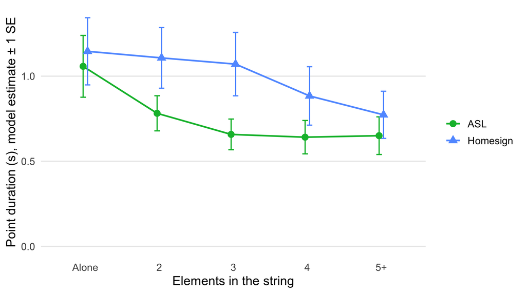

```r
ggplot(fig_s4, aes(length, mean_s, colour = group, shape = group, group = group)) +
  geom_line(position = position_dodge(0.12), linewidth = 0.8) +
  geom_errorbar(aes(ymin = mean_s - se_s, ymax = mean_s + se_s),
                position = position_dodge(0.12), width = 0.15) +
  geom_point(position = position_dodge(0.12), size = 3) +
  scale_colour_manual(values = c(ASL = "#00BA38", Homesign = "#619CFF"), name = NULL) +
  scale_shape_manual(values = c(ASL = 16, Homesign = 17), name = NULL) +
  expand_limits(y = 0) +
  labs(x = "Elements in the string", y = "Point duration (s), model estimate ± 1 SE") +
  theme_minimal(base_size = 13) +
  theme(panel.grid.minor = element_blank(), panel.grid.major.x = element_blank())
```

# 9 Convergence (Table S9)

```r
reported <- list(
  "All points" = m_all,
  "All points + all roles" = m_all_roles,
  "All points + entity vs. other" = m_all_entity,
  "All points + action vs. static" = m_all_action,
  "Isolated points" = m_iso,
  "Isolated + all roles" = m_iso_roles,
  "Isolated + entity vs. other" = m_iso_entity,
  "Isolated + action vs. static" = m_iso_action,
  "With other acts + all roles" = m_with_roles,
  "With other acts + entity vs. other" = m_with_entity,
  "With other acts + action vs. static" = m_with_action,
  "Isolated points, no age intercept" = m_iso_noage,
  "Isolated + all roles, no age intercept" = m_iso_roles_noage,
  "Isolated + entity vs. other, no age intercept" = m_iso_entity_noage,
  "Isolated + action vs. static, no age intercept" = m_iso_action_noage,
  "Isolation by group" = m_ixg,
  "All points, wider priors" = m_all_wide,
  "All points, random-effect SDs Exponential(2)" = m_all_sd2,
  "All points, Gamma likelihood" = m_gamma,
  "Duration by string length (Figure S4)" = m_len)
conv <- bind_rows(Map(convergence, reported, names(reported)))
kable(conv, digits = c(0, 0, 3, 0, 0, 0, 0), row.names = FALSE)
```

| model | N | max_rhat | bulk_ess_fixed | bulk_ess_all | tail_ess_all | divergences |
| --- | --- | --- | --- | --- | --- | --- |
| All points | 2428 | 1.002 | 3622 | 2842 | 3589 | 0 |
| All points + all roles | 2200 | 1.002 | 3860 | 3014 | 4120 | 0 |
| All points + entity vs. other | 2172 | 1.002 | 3827 | 2630 | 3823 | 0 |
| All points + action vs. static | 2172 | 1.002 | 4082 | 3048 | 4149 | 0 |
| Isolated points | 1044 | 1.002 | 3274 | 2470 | 2796 | 0 |
| Isolated + all roles | 941 | 1.002 | 3664 | 2570 | 2712 | 1 |
| Isolated + entity vs. other | 934 | 1.003 | 3473 | 2206 | 2325 | 0 |
| Isolated + action vs. static | 934 | 1.001 | 3436 | 1965 | 2067 | 0 |
| With other acts + all roles | 1234 | 1.002 | 2797 | 2778 | 3900 | 0 |
| With other acts + entity vs. other | 1213 | 1.003 | 3094 | 2766 | 3604 | 0 |
| With other acts + action vs. static | 1213 | 1.002 | 3453 | 3139 | 3590 | 0 |
| Isolated points, no age intercept | 1044 | 1.001 | 2754 | 2189 | 3254 | 0 |
| Isolated + all roles, no age intercept | 941 | 1.003 | 3497 | 2241 | 3533 | 0 |
| Isolated + entity vs. other, no age intercept | 934 | 1.001 | 3317 | 2456 | 3292 | 0 |
| Isolated + action vs. static, no age intercept | 934 | 1.002 | 3345 | 2576 | 3987 | 0 |
| Isolation by group | 2374 | 1.003 | 4228 | 2911 | 4105 | 0 |
| All points, wider priors | 2428 | 1.002 | 3492 | 2441 | 3512 | 0 |
| All points, random-effect SDs Exponential(2) | 2428 | 1.002 | 3952 | 2693 | 3791 | 0 |
| All points, Gamma likelihood | 2428 | 1.001 | 3851 | 2940 | 3965 | 0 |
| Duration by string length (Figure S4) | 1194 | 1.002 | 3018 | 2965 | 3648 | 0 |

# 10 Numbers reported in the manuscript

```r
ci <- function(r, sign = 1) {
  e <- sign * r$estimate; b <- sort(sign * c(r$lower, r$upper))
  sprintf("%.3f [%.3f, %.3f]", e, b[1], b[2])
}
gm <- function(m) { g <- group_means(m)
  paste(sprintf("%s %.2f [%.2f, %.2f]", c("English", "ASL", "homesign"),
                g$mean_s, g$lower, g$upper), collapse = "; ") }
p_range <- function(models, row) {
  v <- sapply(models, function(m) group_contrasts(m)$P[row])
  sprintf("%.3f to %.3f", min(v), max(v))
}
c_all <- group_contrasts(m_all); c_iso <- group_contrasts(m_iso)
sem_all_models <- list(m_all_roles, m_all_entity, m_all_action)
sem_iso_models <- list(m_iso_roles, m_iso_entity, m_iso_action)
excludes_zero <- function(models, row) all(sapply(models, function(m) {
  r <- group_contrasts(m)[row, ]; r$lower > 0 | r$upper < 0 }))

data.frame(
  result = c(
    "All points: convergence (max R-hat; min fixed-effect bulk ESS; divergences)",
    "All points: ASL - English, beta [89% CrI]; P(English > ASL)",
    "All points: homesign - English; P(English > homesign)",
    "All points: ASL - homesign; P(ASL < homesign)",
    "All points: geometric means (s)",
    "Semantic controls, all points: P(English > ASL)",
    "Semantic controls, all points: P(ASL < homesign); intervals exclude 0 in all three",
    "Semantic controls, all points: P(English > homesign); intervals exclude 0 in any",
    "Isolated points: N, children",
    "Isolated points: convergence",
    "Isolated: ASL - English; P(English > ASL)",
    "Isolated: homesign - English; P(English > homesign)",
    "Isolated: ASL - homesign; P(ASL < homesign)",
    "Isolated: ASL - homesign, posterior within +/-0.20",
    "Isolated: geometric means (s)",
    "Semantic controls, isolated: P(English > ASL)",
    "Semantic controls, isolated: P(English > homesign)",
    "Semantic controls, isolated: P(ASL < homesign)",
    "Wider priors: largest change in P",
    "Exponential(2) SD prior: largest change in P",
    "Log-normal vs. Gamma: ELPD difference (SE)"),
  value = c(
    with(convergence(m_all, ""), sprintf("%.3f; %.0f; %d", max_rhat, bulk_ess_fixed, divergences)),
    sprintf("%s; %.3f", ci(c_all[1, ], -1), c_all$P[1]),
    sprintf("%s; %.3f", ci(c_all[2, ], -1), c_all$P[2]),
    sprintf("%s; %.3f", ci(c_all[3, ]), c_all$P[3]),
    gm(m_all),
    p_range(sem_all_models, 1),
    sprintf("%s; %s", p_range(sem_all_models, 3), excludes_zero(sem_all_models, 3)),
    sprintf("%s; %s", p_range(sem_all_models, 2),
            any(sapply(sem_all_models, function(m) { r <- group_contrasts(m)[2, ]; r$lower > 0 | r$upper < 0 }))),
    sprintf("%d, %d", nobs(m_iso), n_distinct(isolated_points$subject)),
    with(convergence(m_iso, ""), sprintf("%.3f; %.0f; %d", max_rhat, bulk_ess_fixed, divergences)),
    sprintf("%s; %.3f", ci(c_iso[1, ], -1), c_iso$P[1]),
    sprintf("%s; %.3f", ci(c_iso[2, ], -1), c_iso$P[2]),
    sprintf("%s; %.3f", ci(c_iso[3, ]), c_iso$P[3]),
    sprintf("%.1f%%", 100 * mean(abs(asl_hs_iso) < 0.20)),
    gm(m_iso),
    p_range(sem_iso_models, 1),
    p_range(sem_iso_models, 2),
    p_range(sem_iso_models, 3),
    sprintf("%.4f", max(abs(shift[2, ] - shift[1, ]))),
    sprintf("%.4f", max(abs(shift[3, ] - shift[1, ]))),
    with(as.data.frame(loo_compare(list(lognormal = loo_lognormal, gamma = loo_gamma))),
         sprintf("%.1f (%.1f)", elpd_diff[2], se_diff[2])))) %>%
  kable()
```

| result | value |
| --- | --- |
| All points: convergence (max R-hat; min fixed-effect bulk ESS; divergences) | 1.002; 3622; 0 |
| All points: ASL - English, beta [89% CrI]; P(English > ASL) | -0.590 [-0.779, -0.381]; 1.000 |
| All points: homesign - English; P(English > homesign) | -0.324 [-0.547, -0.093]; 0.983 |
| All points: ASL - homesign; P(ASL < homesign) | -0.267 [-0.515, -0.017]; 0.954 |
| All points: geometric means (s) | English 1.49 [1.22, 1.79]; ASL 0.83 [0.66, 1.03]; homesign 1.08 [0.86, 1.35] |
| Semantic controls, all points: P(English > ASL) | 0.999 to 0.999 |
| Semantic controls, all points: P(ASL < homesign); intervals exclude 0 in all three | 0.964 to 0.972; TRUE |
| Semantic controls, all points: P(English > homesign); intervals exclude 0 in any | 0.894 to 0.907; FALSE |
| Isolated points: N, children | 1044, 16 |
| Isolated points: convergence | 1.002; 3274; 0 |
| Isolated: ASL - English; P(English > ASL) | -0.314 [-0.594, -0.006]; 0.947 |
| Isolated: homesign - English; P(English > homesign) | -0.277 [-0.561, 0.031]; 0.929 |
| Isolated: ASL - homesign; P(ASL < homesign) | -0.037 [-0.365, 0.301]; 0.575 |
| Isolated: ASL - homesign, posterior within +/-0.20 | 67.9% |
| Isolated: geometric means (s) | English 1.61 [1.27, 1.96]; ASL 1.18 [0.90, 1.50]; homesign 1.22 [0.94, 1.55] |
| Semantic controls, isolated: P(English > ASL) | 0.917 to 0.929 |
| Semantic controls, isolated: P(English > homesign) | 0.832 to 0.860 |
| Semantic controls, isolated: P(ASL < homesign) | 0.649 to 0.681 |
| Wider priors: largest change in P | 0.0052 |
| Exponential(2) SD prior: largest change in P | 0.0044 |
| Log-normal vs. Gamma: ELPD difference (SE) | -7.7 (36.9) |